# PQHS 471 HW1

Youjun Li

Feb 27, 2018

# ISLR Chapter 5

## 9

### a

```r
library(MASS)
data(list="Boston")
df1=Boston
(mu.hat=mean(df1$medv))
```

```
## [1] 22.53281
```

### b

```r
(se.mu.hat=sd(df1$medv)/sqrt(nrow(df1)))
```

```
## [1] 0.4088611
```

The estimated standard error of sample mean (0.41) tells you how accurate your estimate for the population mean is.

### c

For the purpose of practice, I write my own function for boostrap.

```r
btstp=function(x, B, seed, FUN){

  btsm=data.frame(matrix(NA, nrow=length(x), ncol=B)) #will contain all bt samples
  set.seed(seed)
  for (i in 1:B)
  {
   btsm[,i]=sample(x,replace=T)
  }
  thetab=apply(btsm, 2, FUN) #bt estimates from each iteration as a vector
  se.b=sqrt(sum((thetab-(sum(thetab)/B))^2)/(B-1)) #bt standard error
  return(se.b)
}
(se.bt.mu=btstp(df1$medv, 1000, 621, mean))
```

```
## [1] 0.4108423
```

The 1000 bootstrap standard error is slightly bigger than the result from part b.

### d

```r
t.test(df1$medv)
```

```
##
##  One Sample t-test
##
## data:  df1$medv
## t = 55.111, df = 505, p-value < 2.2e-16
## alternative hypothesis: true mean is not equal to 0
## 95 percent confidence interval:
##  21.72953 23.33608
## sample estimates:
## mean of x
##  22.53281
```

```r
c(mu.hat-2*se.bt.mu, mu.hat+2*se.bt.mu)
```

```
## [1] 21.71112 23.35449
```

Since the bootstrap standard error is slightly bigger, the corresponding confidence interval is thus a bit wider than it is of t test.

### e

```r
(med.hat=median(df1$medv))
```

```
## [1] 21.2
```

### f

```r
(se.bt.med=btstp(df1$medv, 1000, 621, median))
```

```
## [1] 0.3720261
```

The bootstrap standard error is 0.37, fairly close to sample mean standard error and sample mean bootstrap standard error.

### g

```r
(mu.01=quantile(df1$medv,0.1))
```

```
##   10%
## 12.75
```

### h

```r
(se.bt.mu01=btstp(df1$medv, 1000, 621, FUN=function(x) quantile(x,0.1)))
```

```
## [1] 0.492929
```

The bootstrap standard error of the tenth percentile is 0.49, larger than it is of mean and median, because the tenth quantile is close to the tail of the distribution.

# ISLR Chapter 6

## 9

### a

```r
library(caret)
df2=read.csv('College.csv', header = T, row.names = 1)
set.seed(621)
dfsplt=createDataPartition(df2$Apps,p=0.7,list = F)
trn=df2[dfsplt,]
tst=df2[-dfsplt,]
```

### b

```r
fit.lm=lm(Apps~., data=trn)
yhat.lm=predict(fit.lm, tst)
(mse.lm=mean((tst$Apps-yhat.lm)^2))
```

```
## [1] 1335636
```

### c

```r
xtrn=model.matrix(Apps~., trn)[,-1]
xtst=model.matrix(Apps~., tst)[,-1]
y=trn$Apps
xtrn=scale(xtrn)
xtst=scale(xtst)
library(glmnet)
fit.rdg=cv.glmnet(xtrn, y, alpha=0)
lmd.rdg=fit.rdg$lambda.min
yhat.rdg=predict(fit.rdg, s=lmd.rdg, newx=xtst)
(mse.rdg=mean((tst$Apps-yhat.rdg)^2))
```

```
## [1] 1159576
```

### d

```r
fit.lss=cv.glmnet(xtrn, y, alpha=1)
lmd.lss=fit.lss$lambda.1se
yhat.lss=predict(fit.lss, s=lmd.lss, newx=xtst)
(mse.lss=mean((tst$Apps-yhat.lss)^2))
```

```
## [1] 1354318
```

```r
coef(fit.lss, s=fit.lss$lambda.1se)
```

```
## 18 x 1 sparse Matrix of class "dgCMatrix"
##                     1
## (Intercept) 2968.0716
## PrivateYes     .
## Accept      3273.0676
## Enroll         .
## Top10perc    340.4257
## Top25perc      .
## F.Undergrad    .
## P.Undergrad    .
## Outstate       .
## Room.Board     .
## Books          .
## Personal       .
## PhD            .
## Terminal       .
## S.F.Ratio      .
## perc.alumni    .
## Expend        79.7488
## Grad.Rate      .
```

```r
coef(fit.lss, s=fit.lss$lambda.min)
```

```
## 18 x 1 sparse Matrix of class "dgCMatrix"
##                       1
## (Intercept) 2968.071560
## PrivateYes  -196.876191
## Accept      3919.049462
## Enroll      -552.432981
## Top10perc    796.164794
## Top25perc   -172.576525
## F.Undergrad    .
## P.Undergrad   69.419226
## Outstate    -301.914099
## Room.Board   133.951098
## Books         28.135347
## Personal       .
## PhD          -90.782169
## Terminal     -88.884424
## S.F.Ratio      .
## perc.alumni   -8.973443
## Expend       372.893267
## Grad.Rate    104.205095
```

I selected lambda.1se because using lambda.min only reduces the dimension by 3, even though it increases the MSE, the MSE is still not significantly larger than it is of ridge regression, and almost the same as it is of lm.

### e

```r
library(pls)
fit.pcr=pcr(Apps~., data=trn, scale=T, validation="CV")
summary(fit.pcr)
```

```
## Data:    X dimension: 545 17
##  Y dimension: 545 1
## Fit method: svdpc
## Number of components considered: 17
##
## VALIDATION: RMSEP
## Cross-validated using 10 random segments.
##        (Intercept)  1 comps  2 comps  3 comps
## CV            3896     3834     2151     2163
## adjCV         3896     3833     2147     2161
##        4 comps  5 comps  6 comps  7 comps
## CV        1931     1818     1703     1683
## adjCV     1818     1815     1695     1675
##        8 comps  9 comps  10 comps  11 comps
## CV        1649     1599      1599      1603
## adjCV     1637     1592      1594      1597
##        12 comps  13 comps  14 comps  15 comps
## CV         1606      1610      1621      1566
## adjCV      1600      1604      1636      1549
##        16 comps  17 comps
## CV         1164      1126
## adjCV      1154      1118
##
## TRAINING: % variance explained
##       1 comps  2 comps  3 comps  4 comps  5 comps
## X       32.47    58.02    65.18    70.55    75.85
## Apps     3.95    70.94    70.94    78.80    80.47
##       6 comps  7 comps  8 comps  9 comps
## X       80.72    84.23     87.6    90.66
## Apps    83.02    83.60     84.3    84.84
##       10 comps  11 comps  12 comps  13 comps
## X        93.12     95.14     96.94     97.92
## Apps     85.18     85.19     85.20     85.20
##       14 comps  15 comps  16 comps  17 comps
## X        98.69     99.34     99.83    100.00
## Apps     85.26     89.72     93.23     93.49
```

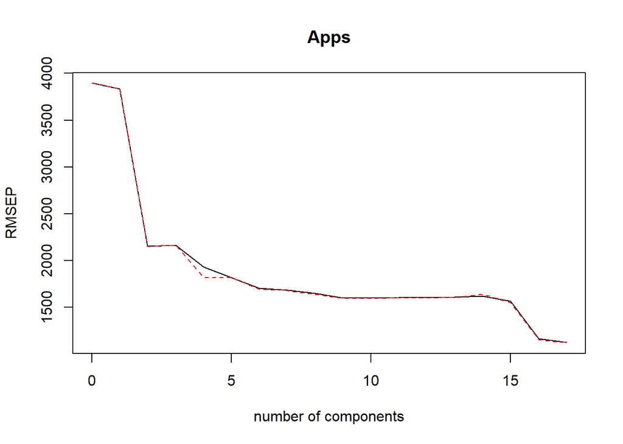

```r
validationplot(fit.pcr, val.type = "RMSE")
```

```r
yhat.pcr=predict(fit.pcr, tst, ncomp=9)
(mse.pcr=mean((tst$Apps-yhat.pcr)^2))
```

```
## [1] 1794196
```

The minimal RMSE is obtained at M=17, but at 9 it’s the elbow point, small enough, so I chose 9.

### f

```r
fit.pls=plsr(Apps~., data=trn, scale=T, validation="CV")
summary(fit.pls)
```

```
## Data:    X dimension: 545 17
##  Y dimension: 545 1
## Fit method: kernelpls
## Number of components considered: 17
##
## VALIDATION: RMSEP
## Cross-validated using 10 random segments.
##        (Intercept)  1 comps  2 comps  3 comps
## CV            3896     1962     1724     1521
## adjCV         3896     1958     1723     1513
##        4 comps  5 comps  6 comps  7 comps
## CV        1444     1242     1171     1159
## adjCV     1417     1216     1159     1148
##        8 comps  9 comps  10 comps  11 comps
## CV        1153     1137      1136      1134
## adjCV     1143     1128      1127      1126
##        12 comps  13 comps  14 comps  15 comps
## CV         1134      1133      1134      1134
## adjCV      1125      1125      1125      1125
##        16 comps  17 comps
## CV         1134      1134
## adjCV      1125      1125
##
## TRAINING: % variance explained
##       1 comps  2 comps  3 comps  4 comps  5 comps
## X       25.99    45.65    63.02    65.33    67.87
## Apps    76.00    82.83    87.34    91.16    93.12
##       6 comps  7 comps  8 comps  9 comps
## X       72.79    77.82    80.84    82.55
## Apps    93.31    93.36    93.41    93.46
##       10 comps  11 comps  12 comps  13 comps
## X        85.86     88.88     91.04     93.02
## Apps     93.47     93.48     93.49     93.49
##       14 comps  15 comps  16 comps  17 comps
## X        95.63     97.13     98.88    100.00
## Apps     93.49     93.49     93.49     93.49
```

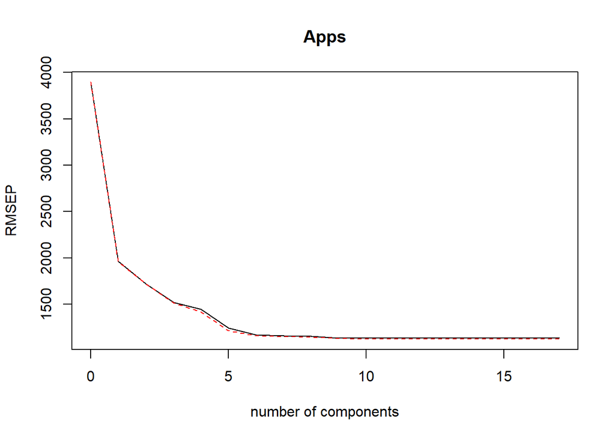

```r
validationplot(fit.pls, val.type = "RMSE")
```

```r
yhat.pls=predict(fit.pls, tst, ncomp=9)
(mse.pls=mean((tst$Apps-yhat.pls)^2))
```

```
## [1] 1361464
```

The minimal RMSE is obtained at M=13, but at 9 it’s only larger by 4, so I chose 9.

### g

In terms of MSE, ridge gives the smallest one. However, LASSO with 1se lambda gives a model with only 3 variables and can still maintain a reasonable MSE. I will consider choosing LASSO more as its MSE is accecptable and significantly redueces the dimension.

## 11

### a

```r
set.seed(621)
dfsplt=createDataPartition(df1$crim,p=0.7,list = F)
trn=df1[dfsplt,]
tst=df1[-dfsplt,]
xtrn=model.matrix(crim~., trn)[,-1]
xtst=model.matrix(crim~., tst)[,-1]
y=trn$crim
xtrn=scale(xtrn)
xtst=scale(xtst)

#forward subset selection
library(leaps)
fit.fwd = regsubsets(crim ~ ., data=trn, nvmax=13, method="forward")
(sum.fwd=summary(fit.fwd))
```

```
## Subset selection object
## Call: regsubsets.formula(crim ~ ., data = trn, nvmax = 13, method = "forward")
## 13 Variables  (and intercept)
##         Forced in Forced out
## zn          FALSE      FALSE
## indus       FALSE      FALSE
## chas        FALSE      FALSE
## nox         FALSE      FALSE
## rm          FALSE      FALSE
## age         FALSE      FALSE
## dis         FALSE      FALSE
## rad         FALSE      FALSE
## tax         FALSE      FALSE
## ptratio     FALSE      FALSE
## black       FALSE      FALSE
## lstat       FALSE      FALSE
## medv        FALSE      FALSE
## 1 subsets of each size up to 13
## Selection Algorithm: forward
##           zn  indus chas nox rm  age dis rad tax
## 1  ( 1 )  " " " "   " "  " " " " " " " " "*" " "
## 2  ( 1 )  " " " "   " "  " " " " " " " " "*" " "
## 3  ( 1 )  " " " "   " "  " " " " " " " " "*" " "
## 4  ( 1 )  " " " "   " "  " " " " " " "*" "*" " "
## 5  ( 1 )  " " " "   " "  "*" " " " " "*" "*" " "
## 6  ( 1 )  "*" " "   " "  "*" " " " " "*" "*" " "
## 7  ( 1 )  "*" " "   " "  "*" "*" " " "*" "*" " "
## 8  ( 1 )  "*" "*"   " "  "*" "*" " " "*" "*" " "
## 9  ( 1 )  "*" "*"   " "  "*" "*" "*" "*" "*" " "
## 10  ( 1 ) "*" "*"   " "  "*" "*" "*" "*" "*" "*"
## 11  ( 1 ) "*" "*"   " "  "*" "*" "*" "*" "*" "*"
## 12  ( 1 ) "*" "*"   " "  "*" "*" "*" "*" "*" "*"
## 13  ( 1 ) "*" "*"   "*"  "*" "*" "*" "*" "*" "*"
##           ptratio black lstat medv
## 1  ( 1 )  " "     " "   " "   " "
## 2  ( 1 )  " "     " "   " "   "*"
## 3  ( 1 )  "*"     " "   " "   "*"
## 4  ( 1 )  "*"     " "   " "   "*"
## 5  ( 1 )  "*"     " "   " "   "*"
## 6  ( 1 )  "*"     " "   " "   "*"
## 7  ( 1 )  "*"     " "   " "   "*"
## 8  ( 1 )  "*"     " "   " "   "*"
## 9  ( 1 )  "*"     " "   " "   "*"
## 10  ( 1 ) "*"     " "   " "   "*"
## 11  ( 1 ) "*"     "*"   " "   "*"
## 12  ( 1 ) "*"     "*"   "*"   "*"
## 13  ( 1 ) "*"     "*"   "*"   "*"
```

```r
which.min(sum.fwd$cp) # 6 according to Cp
```

```
## [1] 6
```

```r
which.min(sum.fwd$bic) # 2 according to BIC
```

```
## [1] 2
```

```r
which.max(sum.fwd$adjr2) # 7 according to adj R2
```

```
## [1] 7
```

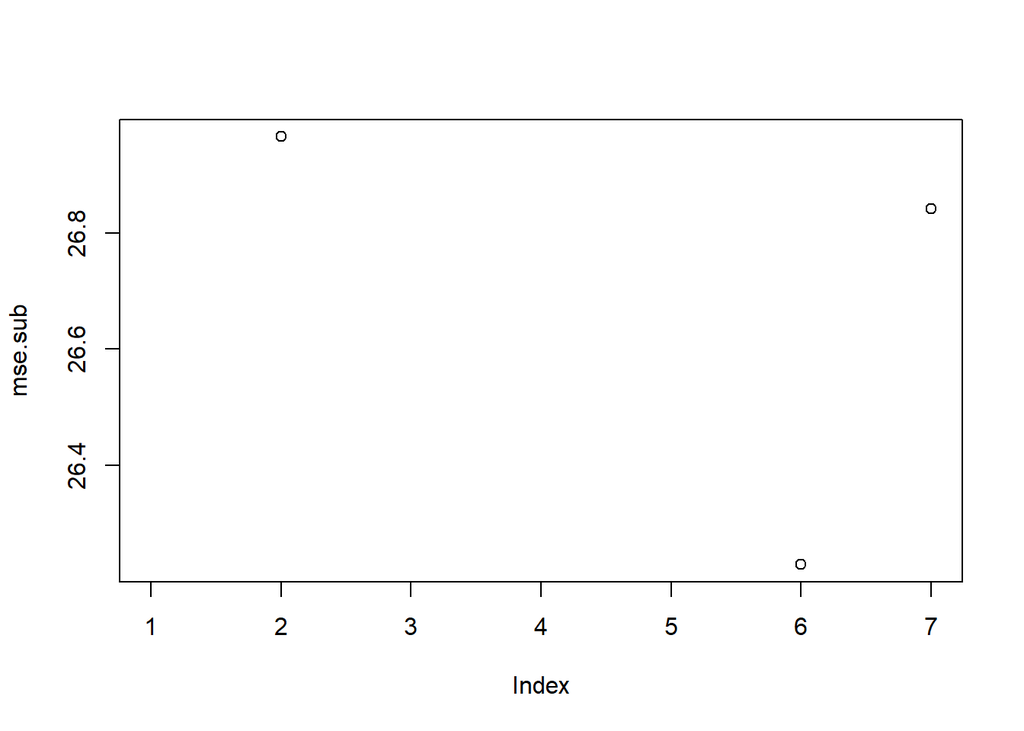

```r
xtest = model.matrix(crim ~ ., tst)
mse.sub=c()
for (i in c(2,6,7)) {
    coefi = coef(fit.fwd, id = i)
    pred = xtest[, names(coefi)] %*% coefi
    mse.sub[i] = mean((tst$crim - pred)^2)
}
plot(mse.sub) #plot suggests 6
```

```r
mse.sub[6]
```

```
## [1] 26.23006
```

```r
#model 6 is zn+nox+dis+rad+ptratio+medv

#ridge
fit.rdg=cv.glmnet(xtrn, y, alpha=0)
lmd.rdg=fit.rdg$lambda.min
yhat.rdg=predict(fit.rdg, s=lmd.rdg, newx=xtst)
(mse.rdg=mean((tst$crim-yhat.rdg)^2))
```

```
## [1] 24.27327
```

```r
coef(fit.rdg, s=fit.rdg$lambda.min)
```

```
## 14 x 1 sparse Matrix of class "dgCMatrix"
##                      1
## (Intercept)  3.6940692
## zn           0.7830149
## indus       -0.5318347
## chas        -0.1596021
## nox         -0.8722577
## rm           0.4957347
## age          0.3013394
## dis         -1.6735523
## rad          3.8326869
## tax          0.8134454
## ptratio     -0.3929157
## black       -0.3537283
## lstat        0.5861143
## medv        -1.8928787
```

```r
#lasso
fit.lss=cv.glmnet(xtrn, y, alpha=1)
lmd.lss=fit.lss$lambda.min
yhat.lss=predict(fit.lss, s=lmd.lss, newx=xtst)
(mse.lss=mean((tst$crim-yhat.lss)^2))
```

```
## [1] 24.761
```

```r
#coef(fit.lss, s=fit.lss$lambda.1se)
coef(fit.lss, s=fit.lss$lambda.min)
```

```
## 14 x 1 sparse Matrix of class "dgCMatrix"
##                       1
## (Intercept)  3.69406916
## zn           0.82932317
## indus       -0.34498978
## chas        -0.07402932
## nox         -0.92427530
## rm           0.42800752
## age          0.14273593
## dis         -1.81141296
## rad          4.81903548
## tax          .
## ptratio     -0.48958723
## black       -0.19567757
## lstat        0.30145186
## medv        -2.20954719
```

```r
#pcr
fit.pcr=pcr(crim~., data=trn, scale=T, validation="CV")
summary(fit.pcr)
```

```
## Data:    X dimension: 356 13
##  Y dimension: 356 1
## Fit method: svdpc
## Number of components considered: 13
##
## VALIDATION: RMSEP
## Cross-validated using 10 random segments.
##        (Intercept)  1 comps  2 comps  3 comps
## CV           9.108    7.745    7.740    7.381
## adjCV        9.108    7.741    7.736    7.375
##        4 comps  5 comps  6 comps  7 comps
## CV       7.402    7.395    7.473    7.484
## adjCV    7.393    7.388    7.462    7.471
##        8 comps  9 comps  10 comps  11 comps
## CV       7.471    7.449     7.478     7.486
## adjCV    7.459    7.427     7.457     7.467
##        12 comps  13 comps
## CV        7.381     7.295
## adjCV     7.359     7.273
##
## TRAINING: % variance explained
##       1 comps  2 comps  3 comps  4 comps  5 comps
## X       46.50    59.83    69.14    75.98    82.62
## crim    28.68    28.83    35.55    35.83    35.93
##       6 comps  7 comps  8 comps  9 comps
## X       87.63    91.00    93.19    95.29
## crim    36.38    36.77    38.02    39.11
##       10 comps  11 comps  12 comps  13 comps
## X        97.09     98.47     99.56    100.00
## crim     39.22     39.28     41.43     42.79
```

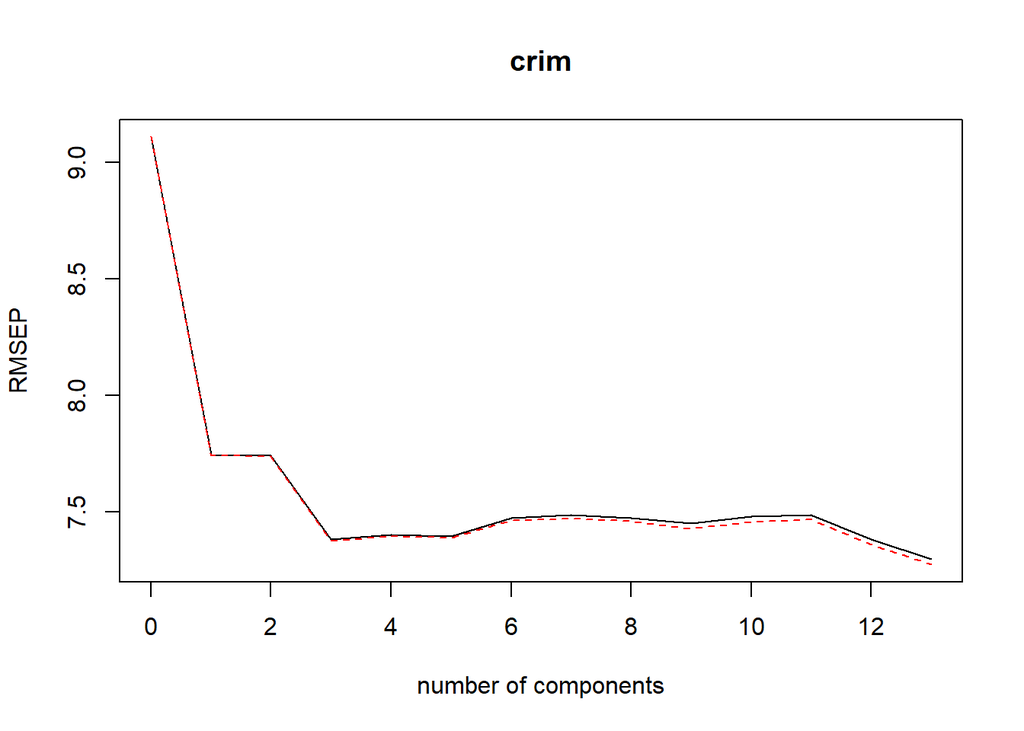

```r
validationplot(fit.pcr, val.type = "RMSE")
```

```r
yhat.pcr=predict(fit.pcr, tst, ncomp=3) #although comps 13 is 0.128 less than comps 3, its small
(mse.pcr=mean((tst$crim-yhat.pcr)^2))
```

```
## [1] 26.36865
```

### b and c

Ridge regression gives the smallest test MSE (24.27) but included all 13 variables. The forward subset selection performs the third best in terms of test MSE (26.23), and it gives a smaller model with 6 variables: zn+nox+dis+rad+ptratio+medv. Even though LASSO with 1se lambda would give the most parsmonious model with only one variable, its MSE is big: 38.74. So this time I went with the minimum lambda that gives the second smallest test MSE (24.76) and a model with 12 variables: zn+indus+chas+nox+rm+age+dis+rad+ptratio+black+lstat+medv. In this case, I think I will choose the forward subset selection as it gives a much smaller model with accecptable test MSE.